# P2 - Perceptron learning rule

## Richard Jansen 1762581

[figure not shown]

```python
import perceptron_mod as im
import perceptronLayer_mod as ptl
import perceptronNetwork_mod as ptn
from sklearn.metrics import accuracy_score
import random

from itertools import product # for truth table
```

```python
random.seed(1762581)
```

```python
def random_number_list(size_n):
    randomnumber_list = []
    for ri in range(size_n):
        randomnumber_list.append(round(random.random()*10,1))
    return randomnumber_list

def random_number_float():
    return random.randint(-10, 10)
```

```python
random.randint(-10, 10)
```

```
-3
```

```python
random_number_list(2)
```

```
[1.2, 2.1]
```

## AND Perceptron

Train de perceptron tot het de AND-functie heeft geleerd. Initialiseer een perceptron met willekeurige startwaarden. Wat zijn de uiteindelijke parameters van de perceptron?

```python
expected_output_and = (([1, 1], [True]),
                       ([1, 0], [False]),
                       ([0, 1], [False]),
                       ([0, 0], [False]))
```

```python
AND1 = im.InputNW(inputWeight=random_number_list(2), bias=random_number_float(), idPerceptron='AND 1')
AND1.activate([1,1])

print(f"The start values of the Perceptron \/\n{AND1}The Error = {AND1.error(expected_output_and)}\n")

AND1.update(expected_output_and, epoch=5000)
AND1.activate([1, 1])

print(f"The Ending values of the Perceptron \/\n{AND1}The Error = {AND1.error(expected_output_and)}\n")
```

```
The start values of the Perceptron \/
This is a AND 1 Perceptron and has [1, 1] as input and has [4.4, 8.5] as weights and has -1 as bias and output of this perceptron = True
 The Error = 0.5

The Ending values of the Perceptron \/
This is a AND 1 Perceptron and has [1, 1] as input and has [3.200000000000001, 5.300000000000011] as weights and has -5.399999999999998 as bias and output of this perceptron = True
 The Error = 0.0
```

## XOR Perceptron

Train de perceptron tot het de XOR-functie heeft geleerd. Initialiseer een perceptron met willekeurige startwaarden. Wat zijn de uiteindelijke parameters van de perceptron?

```python
expected_output_XOR =  (([1, 1],[False]),
                    ([1, 0],[True]),
                    ([0, 1],[True]),
                    ([0, 0],[False]))
expected_output_XOR
```

```
(([1, 1], [False]), ([1, 0], [True]), ([0, 1], [True]), ([0, 0], [False]))
```

```python
XOR1 = im.InputNW(inputWeight=random_number_list(2), bias=random_number_float(), idPerceptron='XOR 1')
XOR1.activate([1,1])

print(f"The start values of the Perceptron \/\n{XOR1}The Error = {XOR1.error(expected_output_XOR)}\n")

XOR1.update(expected_output_XOR, epoch=5000)
XOR1.activate([1, 1])

print(f"The Ending values of the Perceptron \/\n{XOR1}The Error = {XOR1.error(expected_output_XOR)}\n")
```

```
The start values of the Perceptron \/
This is a XOR 1 Perceptron and has [1, 1] as input and has [5.0, 7.4] as weights and has 7 as bias and output of this perceptron = True
 The Error = 0.5

The Ending values of the Perceptron \/
This is a XOR 1 Perceptron and has [1, 1] as input and has [0.20000000000000104, 0.10000000000000991] as weights and has -0.09999999999999193 as bias and output of this perceptron = True
 The Error = 0.25
```

Een Xor gate is niet lineair scheidbaar en daarvoor niet mogelijk om met 1 perceptron te maken

# Iris DataSet

[figure not shown]

# Analyse

De Iris data set bevat 3 soort bloemen die geclassificeerd kunnen worden, zoals hierboven staat weergegeven zijn er 4 features tot onze beschrikken in deze dataset.

Een enkele perceptron kan alleen onderscheid maken tussen 2 dingen en niet 3 dingen. Mijn verwachting zou zijn dat als je 1 Perceptron gebruikt voor alle 3 tegelijk, dat je een maximale accuraty van 33% zou kunnen halen (wel of niet een specifieke bloem) Zie uitwerking hier onder dat mijn voorspelling correct is 😊

De correcte aanpak zou zijn om meerdere layers tebruiken en dan backpropagation te gebruiken maar dat valt buiten de scope van de opdracht dussss… dan maar alleen de Setosa en Versicolor onderscheiden

# Setosa en Versicolor

```python
from sklearn.datasets import load_iris
```

```python
dataset = load_iris()
```

```python
dataSeVi = dataset['data'].tolist()[:100]
targetSeVi = dataset['target'][:100]
target_namesSeVi = dataset['target_names'][:2]
feature_namesSeVi = dataset['feature_names']
targetSeVi = [[x] for x in targetSeVi]
expected_resultsSeVi = tuple(zip(dataSeVi, list(targetSeVi)))
```

```python
SeViFlowers = im.InputNW(inputWeight=random_number_list(len(feature_namesSeVi)), bias=random_number_float(), idPerceptron='SeViFlowers')
SeViFlowers.activate([0,0,0,0])
print(SeViFlowers)

SeViFlowers.update(expected_resultsSeVi, epoch=5000)
print(SeViFlowers)
```

```
This is a SeViFlowers Perceptron and has [0, 0, 0, 0] as input and has [7.6, 2.4, 5.3, 7.2] as weights and has -3 as bias and output of this perceptron = False

This is a SeViFlowers Perceptron and has [5.7, 2.8, 4.1, 1.3] as input and has [0.1499999999999998, -2.650000000000001, 3.1100000000000008, 6.860000000000005] as weights and has -4.499999999999999 as bias and output of this perceptron = True
```

```python
output = []
for idex,value in enumerate(range(len(dataSeVi))):
    SeViFlowers.activate(dataSeVi[idex])
    output.append(SeViFlowers.getOutput())
```

```python
accuracy_score(targetSeVi, output)
```

```
1.0
```

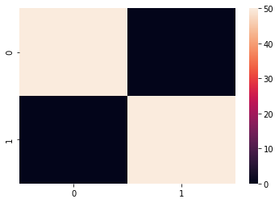

```python
import seaborn as sns
from sklearn.metrics import confusion_matrix
sns.heatmap(confusion_matrix(targetSeVi, output))
```

# 100% Accuracy!!!

was te verwachten, dit probleem is linear goed scheidbaar

De uiteindelijke parameters zijn [0.1499999999999998, -2.650000000000001, 3.1100000000000008, 6.860000000000005] als weights

en -4.499999999999999 als bias

## Alle 3 de bloemen

```python
from sklearn.datasets import load_iris
```

```python
dataset = load_iris()
```

```python
data = dataset['data'].tolist()
target = dataset['target']
target_names = dataset['target_names']
feature_names = dataset['feature_names']
target = [[x] for x in target]
expected_results = tuple(zip(data, list(target)))
```

```python
threeFlowers = im.InputNW(inputWeight=random_number_list(len(feature_names)), bias=random_number_float(), idPerceptron='threeFlowers')
threeFlowers.activate([0,0,0,0])
print(threeFlowers)

threeFlowers.update(expected_results, epoch=5000)
print(threeFlowers)
```

```
This is a threeFlowers Perceptron and has [0, 0, 0, 0] as input and has [2.0, 3.3, 2.4, 8.3] as weights and has -9 as bias and output of this perceptron = False

This is a threeFlowers Perceptron and has [5.9, 3.0, 5.1, 1.8] as input and has [39574.059999984864, -11331.589999999427, 102258.84000000898, 44509.39000010047] as weights and has -4.600000000000016 as bias and output of this perceptron = True
```

```python
output = []
for idex,value in enumerate(range(len(data))):
    threeFlowers.activate(data[idex])
    output.append(threeFlowers.getOutput())
```

```python
accuracy_score(target, output)
```

```
0.3333333333333333
```

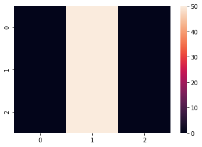

```python
import seaborn as sns
from sklearn.metrics import confusion_matrix
sns.heatmap(confusion_matrix(target, output))
```

# 33,33% accuracy !!!!

Mijn voorspelling is correct, er is een accuratie van 33% gehaald

De uiteindelijke parameters zijn [39574.059999984864, -11331.589999999427, 102258.84000000898, 44509.39000010047] als weights

en -4.600000000000016 als bias